# Putting the **AI** in **A**ppl**I**ed Urban Modelling

A Complete Model of Brighton and Hove’s Secondary School System in Five Months

Prof Adam Dennett FRGS FAcSS

Bartlett Centre for Advanced Spatial Analysis, UCL

Thursday 15 October 2026

# Background

## Who I am, and why this talk

- I am a Professor of Urban Analytics at UCL’s Centre for Advanced Spatial Analysis (CASA). I build spatial models — of migration, of housing, of how people move around cities.
- I am also a parent in Brighton & Hove and became involved in a two-year argument with the council, along with hundreds of families, about changes to secondary school admissions.
- A misalignment between:
  - the stated aims of the council (improving disadvantaged student attainment)
  - stated challenges (declining pupil roll, viability issues for some schools)
  - policies implemented (admission priority changes, catchment boundary alterations and PAN reductions)
- with insufficient consideration given to complex system interactions and negative externalities

## Who I am, and why this talk

- I spent 2-years analysing data to understand the drivers of secondary attainment

[figure not shown]

  *https://adamdennett.github.io/school_attainment_tool/*
- Conclusion: Council policies unlikely to improve attainment, costs including increased travel, breakdown of community schooling etc., not weighed appropriately, biggest issue - absence - not acknowledged in policy decisions
- Secondary policy impacts - unintended consequences - poorly understood

## Background - Problems in the Brighton and Hove School System

- Some children have no secondary school near their home
- Declining pupil numbers with some schools affected more than others
- Policies promoting “choice” funnelling children away from peripheral schools already struggling for numbers
- Lots of engaged Parents, Schools, Councillors and Pressure Groups but a poor general understanding - *Collective Intelligence* - about how the whole system operates or how we might fix it to solve the interconnected challenges of attainment, absence, access and viability
- “Solutions” *without asking the right questions*

## The Brighton and Hove Secondary School System

[interactive chart not shown]

Figure 1: Schools and Pupils in Brighton and Hove

## The cohort is already falling

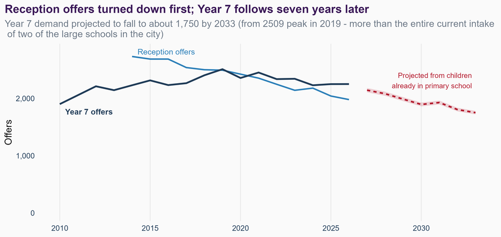

## Income is tied to numbers - and financial reserves are running out

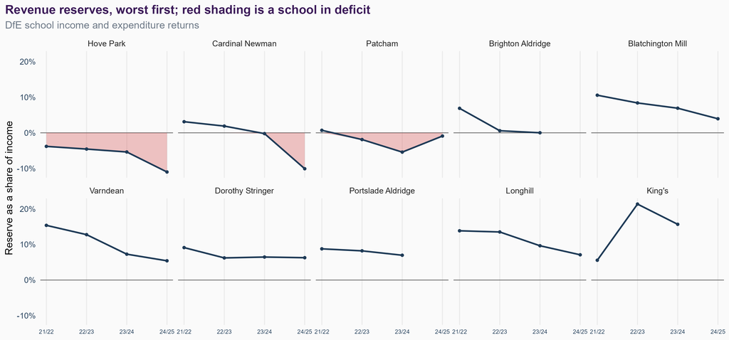

## School Allocations and Viability

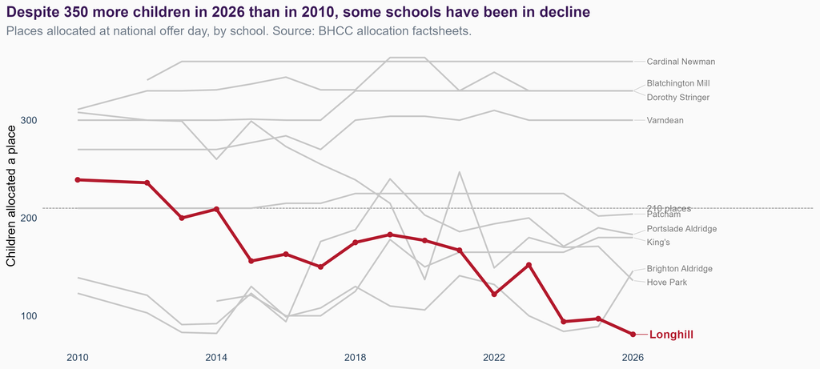

The city placed **1,900 children in 2010 and 2,250 in 2026**. Over the same years **Longhill fell from 239 to 81**, and **Hove Park from 308 to 136**. Now the pupil roll is declining, serious problems ahead

## An AI4CI problem, if ever there was one

- The **UKRI National AI Research Hub for Collective Intelligence** - 5-year, £12m EPSRC Project - asks what AI can do to enhance the thinking groups of people do together and the solutions they can arrive at.
- Can AI help us develop a **shared, inspectable account of how the school system in Brighton and Hove actually behaves**?
- The challenge: *If AI can help us get to an answer quicker - can I ask the right questions? Can this collaborative effort enhance our Collective Intelligence?*

[figure not shown]

A system where everyone is well informed about a *part* and nobody can see the *whole* is not an information problem. It is a collective intelligence problem.

## Why AI made this tractable

**What was expensive before**

- Harmonising a dozen published sources that do not share a key
- Building, calibrating and auditing a city-scale model
- Re-running everything when one assumption changes
- Writing it all down clearly enough for a non-specialist to check
- Turning it into something a parent/school leader/councillor/council officer can actually use

**What that cost collapsing buys**

- Scenarios can be *tested* rather than asserted
- The work is **auditable**: every figure traces to code and a source
- A stakeholder can move a slider, change a number, see a knock-on impact themselves instead of taking my word for it
- Being wrong becomes cheap, so questions get asked that were not worth a week of someone’s time (*“if we move/shrink school A, what happens to demand at school B?”*)

The point is not that AI did the analysis. It is that AI made *ideas scalable and testable*, with a short timeline, *big urban models achievable* the analysis **sharable and replicable** — one person could build something the whole city can interrogate, argue with, and use. That is the collective intelligence bit.

# The Model

## What exists now

| The thing | Scale |
| --- | --- |
| A strategic analysis of the city’s school system | 9,712 lines of Quarto |
| A technical guide auditing every model term | 4,736 lines |
| The model itself, plus data assembly | ~7,400 lines of R |
| An interactive policy simulator (Shiny) | ~3,000 lines |
| A private analysis repository | ~8,200 lines |
| Three slide decks | ~3,500 lines |
| Commits across six repositories | 805 |

- A production-constrained spatial interaction model with a competing-destinations term, calibrated per catchment, fitted against the council’s published offer data.
- It reproduces the September 2026 allocations with an *R² of 0.95*.

## Questions I wanted to Answer

> I won’t answer these all today - but will show how they can now all be answered
- What is causing Longhill School’s acute numbers problem - is it geography, demography, attractiveness, some combination or something else?
  - How do parents in the city choose which schools to send their children to - what makes a school attractive? What if parents chose differently?
- Would moving Longhill and/or shrinking it:
  - Help it survive in the medium term - 2035?
  - Improve accessibility or segregation in the city?
- How do current and previously proposed policies impact pupil displacement (students unable to attend their local school)?
- Given how the system operates, what policy levers can be pulled to maintain a viable school system in the city, 10 years from now?

## How I answered them - the model

A **spatial interaction model**: the same family of model used for commuting, migration and retail catchments. It predicts how many children flow from each neighbourhood to each school, given where they live, how far each school is, and how much they want to go there.

$$T_{ij} \;=\; A_i\,O_i\;\;W_j\;\;c_{ij}^{-\beta}\;\;e^{\gamma_h}\;\;C_j^{\delta}$$

| Term | What it is |
| --- | --- |
| $T_{ij}$ | children from neighbourhood $i$ to school $j$ |
| $O_i$ | children living in $i$ — 195 neighbourhoods |
| $W_j$ | how attractive school $j$ is |
| $c_{ij}$ | bus-and-walk journey time, $i$ to $j$ |
| $e^{\gamma_h}$ | the catchment bonus, if $j$ is in $i$’s catchment |
| $C_j$ | how much competition $j$ has nearby |
| $A_i$ | the balancing term |

It is **production-constrained**: $A_i$ forces every child living somewhere to end up somewhere. The model never invents or loses children — it only decides where they go.

That is what makes it useful for policy. Close a school, move one, cut its admission number, and the children do not vanish. They reappear somewhere else, and the model says where.

## What the model had to learn

Three things are fitted to the council’s own published allocations, rather than assumed:

**Distance decay,** $\beta = 1.7$. How sharply demand falls as a school gets further away.

**The catchment pull,** $\gamma_h$. How much living inside a catchment raises the odds of choosing a school there — fitted **separately for each catchment**, because they do not behave alike.

**Competition,** $\delta = 0.3$. Whether being surrounded by rivals helps a school or hurts it.

Living in the catchment multiplies the odds by **2.7× in Brighton Aldridge’s** and **13.5× in Stringer and Varndean’s** — one policy doing five times as much work in one place as another.

Fitted this way, the model reproduces the 2026 offers with an **R² of 0.95**.

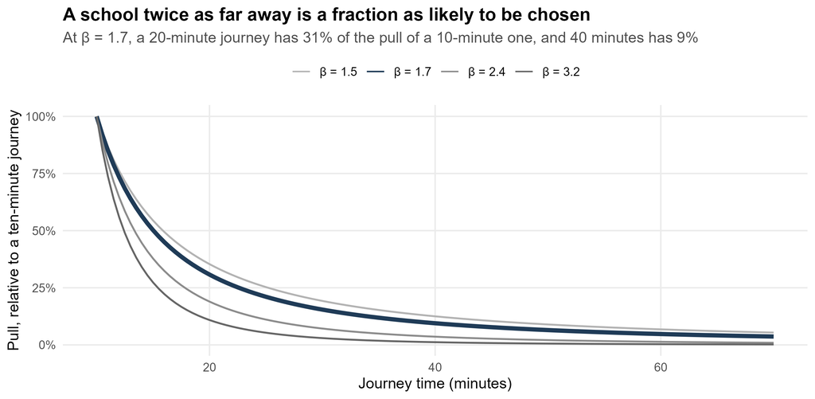

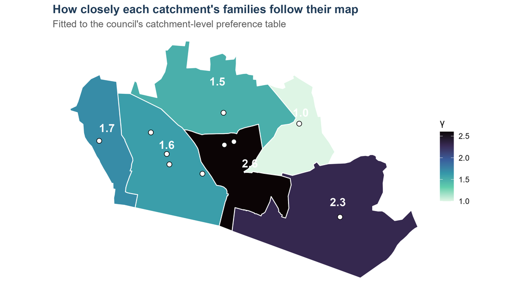

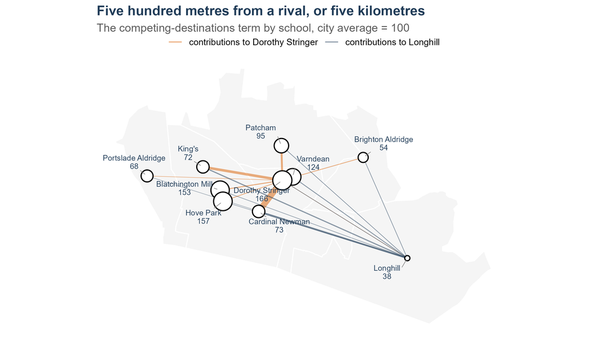

## What $c_{ij}$ actually means

[interactive chart not shown]

Figure 2: One neighbourhood in the Stringer/Varndean catchment to Brighton Aldridge. Walking legs orange and dashed, bus legs blue. Routed on the real timetable at 08:00.

**3.0 km as the crow flies. 35 minutes, 5 legs, two buses — the 50 then 28 — and 1 change.** Every one of the 2,925 origin-school pairs in the model is routed like this, on the real timetable. That is what $c_{ij}$ is.

## Attractiveness - $W_{j}$ = Exam Scores

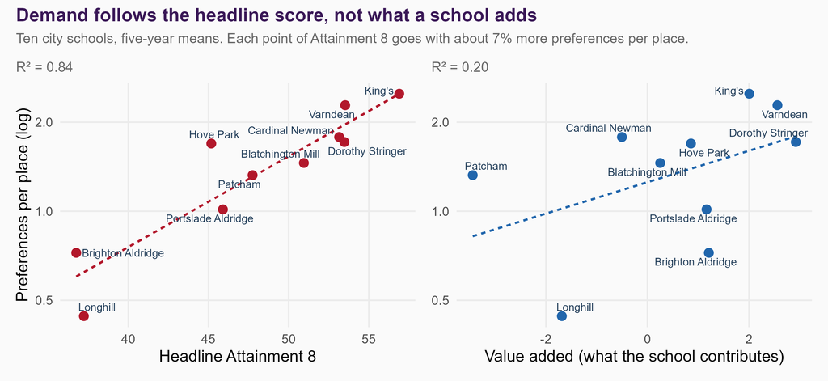

The council’s secondary admissions guide tells parents to look at each school’s *“National Curriculum test results, public exam results”* and its Ofsted reports: figures that mostly describe who a school admits.

# The Process

## This started before April

**2007-2026.** 20-years of wrapping my head around spatial interaction models in different contexts from migration to retail

**October 2024.** Brighton & Hove is consulting on redrawing its catchments. I write `BrighonSchoolsSIM.qmd` — **1,014 lines** of R and Quarto. A production-constrained spatial interaction model of the city’s schools.

I call the hypothetical baseline **Brightopia**: where every child would go if distance were the only thing that mattered.

**December 2024.** I write `bus_routes.qmd` — **1,021 lines** — setting up `r5r`, a GTFS feed and an OSM extract to compute real public-transport journey times to every school.

**2025-2026.** Months of work on drivers of attainment in England, feeding into attractiveness inputs

Two thousand lines of spatial interaction modelling and routing, written by hand, eighteen months before any of this.

That is what the new model was built **on**, not instead of.

Brightopia is still in the current document, as the $W_j = 1$ baseline the calibrated model is measured against.

## The record I am drawing on

Claude Code keeps a transcript of every session: every instruction I typed, every action it took, timestamped.

For this talk I parsed **~250 MB of those logs** across ten sessions, plus the git history of six repositories.

So the numbers that follow are counted, not remembered. They are also **a snapshot** — the work is still going.

**1,277** instructions from me.

**13,451** tool calls from Claude.

**69** working days, spread over 166.

About **ten and a half actions for every sentence I typed**.

## Five months, in one chart

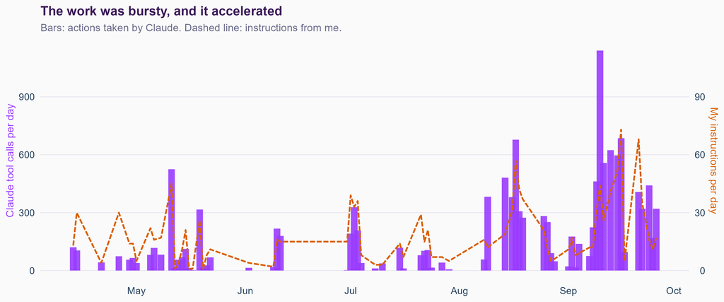

Figure 3

## What the 13,451 actions actually were

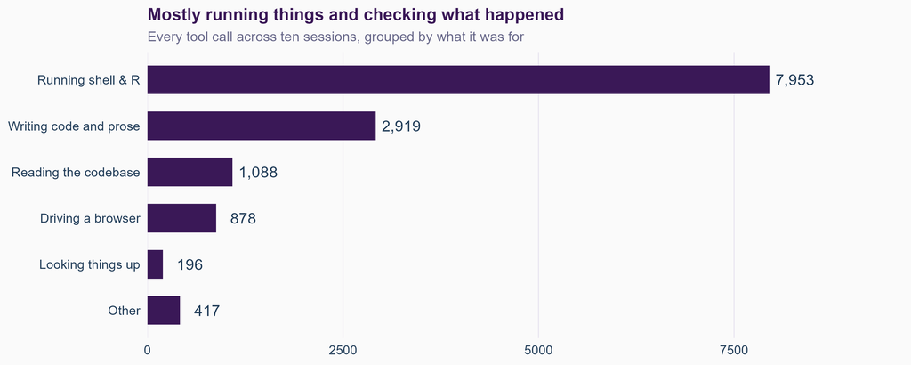

Figure 4

The largest single category is not writing code. It is **running code and reading the result** — the loop that turns a plausible script into a correct one.

## The division of labour

**What I brought**

- **The working prototype** — Brightopia, and the `r5r` routing pipeline, both written by hand in 2024
- Twenty years of building spatial interaction models: knowing that attractiveness, distance decay and competing destinations were the terms that mattered
- Knowledge of the school system, and of the city’s politics
- Judgement about what is defensible to publish
- Knowing when an answer was wrong
- Every decision about what to do next

**What Claude brought**

- Scale: a hand-built prototype turned into a calibrated, audited system
- Data wrangling across a dozen published sources
- Shiny, deployment, rendering, version control
- Debugging, and the patience for it
- Documentation written as it went
- The willingness to redo all of it when one assumption changed

I knew what to ask for and what to examine, because I had built a smaller version of it myself. **That is not a small part of why this worked.**

## What my instructions actually look like

Verbatim, from the logs. The counts are the tool calls that followed.

> **“fonts as well”**

> *13 characters → 58 actions*

> **“yes, build it”**

> *13 characters → 46 actions*

> **“yes, add Priory, Seahaven and Seaford Head as destinations”**

> *58 characters → 68 actions*

> **“Can you cite the sources and link to all of the data that is used in each section please then commit and push as I’m going to bed”**

> *128 characters → 52 actions*

Median instruction: **199 characters**. About thirty-six words.

## 14–16 August: extending my own model

**14 August**

> “All of the code we need to extend the road network is contained within the original **`BrighonSchoolsSIM.qmd`** file… We use **R5R** to build the network… the new thing we can do to extend the bus network down to Peacehaven is use the **UK2GTFS** package.”

My own file, my own method, and the specific package to go further with it.

**16 August, 07:15**

> “The Dorothy Stringer intake is modelled as low and interpreted as **bad location**. However, this isn’t quite right… Stringer is low **not because it is inaccessible, but because it is central and close to other schools** that the model fills up more favourably. So this is a problem **inherent in this model**.”

The right number, reached by the wrong mechanism - correction on the interpretation.

## 16–18 August: what to measure, and why it holds

**16 August, 21:49**

> “**Ascribing IDACI values to modelled students** going into schools in the spatial interaction model could give us a sense of the likely profile of disadvantage at each school.”

This became the entire disadvantage layer.

**18 August**

> “No matter what ideological political thinking might hope — **and this is the problem with ideology, it rarely survives coming into contact with reality** — across human systems the world over, **distance decay is a universal truth**, whether it relates to schools, retail, migration, commuting, health care accessibility or any other human process.”

Not a fact to look up (more of a rant at Claude! 😂): knowing which seventy years of literature the city’s argument was about to collide with.

## 10 September: specifying the model

**11:17**

> “Re-running the Brightopia model with $W_j$ attractiveness set to weighted preferences and using the **new** $c_{ij}$ matrix which fixed some of the travel times — where before we had some weird bus journeys where walking would have been faster — and with **setting the beta value to 1.7**.”

**13:26, two hours later**

> “Can we add in a **competing destinations term** too, to see if that fixes the Blatch / Hove Park under/over prediction… Also, we might need a **catchment term** in there too.”

## Catching Errors - In Prompts

Verbatim from the prompts. Four different kinds of wrong.

**A statistic that cannot be true**

> “I’m not sure the ‘where that would rank’ percentage in the attainment tab table is correct for the value added drop down — **every school appears to be in the 99th or 100th percentile.**”

**The wrong input data entirely**

> “The ‘system as it stands’ in the open report **is incorrect**. The catchment areas in that map relate to the **pre-2024** consultation catchment areas.”

**Geometry that could not exist**

> “The Stringer Varndean catchment **can’t be that big and weird shaped**, and the BACA catchment can’t extend down over the alternative Longhill site — this needs to be scrapped.”

**History the data does not contain**

> “Up until last year, **Whitehawk was in the Longhill catchment**… so for a long time Longhill did have a large number of students from deprived areas in its catchment. **I’m not sure if this is properly represented in the model?**”

None of these is gibberish. Each is plausible, well-formatted and confidently presented — and each needed someone who knew either the statistics or the city. The last one needed knowledge of the city’s own history, which is in no dataset anywhere.

## The workflow

Everything is **Quarto**. The analysis document, the technical guide, the slide decks — all `.qmd`, all executing live R against the same data.

The loop, many times a day:

1. I say what I want, usually in two or three sentences
2. Claude edits the source and runs it
3. It renders, screenshots, checks the numbers
4. It commits and pushes
5. I read the rendered output and react

The document **is** the analysis. There is no separate “writing up” — changing the model changes the paragraph that describes it, because the paragraph is generated from the model.

Git is the memory. 805 commits, each with a message explaining why.

## Why my Quarto workflow matters more than it sounds

When I asked “does the Hove Park change affect section 5.5?”, that was answerable — because section 5.5 is code, and the code re-runs.

When I asked for the commentary to be rebuilt with the new numbers, no one had to re-type any numbers.

Reproducibility stops being a virtue you aspire to and becomes the only way the thing can work at this speed. If the outputs were hand-copied into Word, none of this would survive its own rate of change.

## The recursion

The interesting part is not that AI wrote code. It is the workflow **loop**:

1. A model produces a result.
2. The result goes into a document, written to be read by me/stakeholders
3. Ask AI to write a lay-commentary as it goes - Writing it clearly exposes holes or errors.
4. The holes/error becomes a new question for the model.
5. Answering it changes the model — and the document rewrites itself.
6. Iterate around again

That cycle ran perhaps two hundred times. Each turn took minutes, not weeks. **That compression is the whole story.**

The process not dissimilar to supervising PhD students or Research Assistants - iteration occurs in minutes rather than weeks.

## Eighteen days

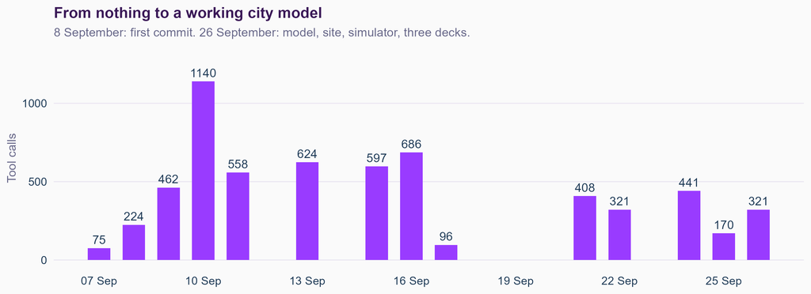

Figure 5

## Worked example: the simulator

[figure not shown]

- Simulator has both pre-built scenarios I imagined plus scope to change each element.
- Built in about two days. “what if” questions became cheap to ask multiple times

## Back to the first question

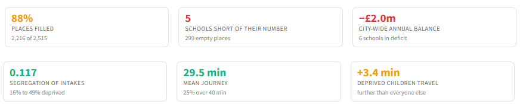

> *“What is causing Longhill’s acute numbers problem — is it geography, demography, attractiveness, some combination or something else? Would moving and/or shrinking it help it survive, or improve anything else?”*
- The honest answer is **none of them on their own**.
- Longhill is not short of children for one reason, so no single lever fixes it.
- What the simulator lets you do is pull them **one at a time, and watch them compound**.
- KPIs at the top of the simulator - **Today, 2026.**
  - Longhill takes **90 of 210 places (modelled) (43%)**, 120 short.
  - A disadvantaged child travels **+3.4 minutes further** than everyone else.

## 1st Lever: Families select on value-added, not attainment

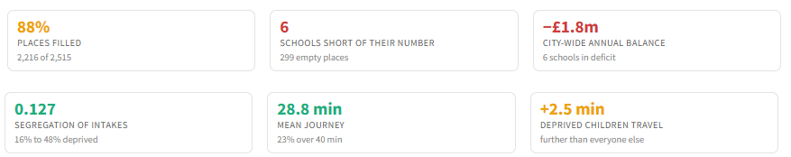

[figure not shown]

One dropdown. Families read the **four-year value added measure** — what a school adds once its intake is accounted for — as closely as they now read the headline score. Nothing about the schools changes.

Longhill goes from **90** to **106 of 210 (50%)**.

The travel gap falls from **+3.4** to **+2.5 minutes**, and the city’s mean journey drops by 42 seconds. Segregation increases slightly.

## 2nd Lever: Move Longhill, revert its catchment

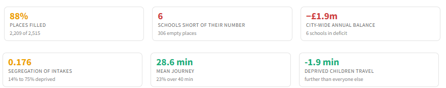

[figure not shown]

Two more controls: Longhill relocates to **Elm Grove**, and **Whitehawk returns to Longhill catchment** pre-2024 consultation

Redrawing the catchments as flow regions around the new site was also tested. It did **worse** — a travel gap of −1.0 against −1.9, and twice the displacement.

## 3rd Lever: and if added value like BACA

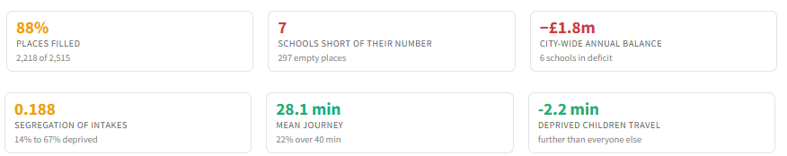

[figure not shown]

The last lever is not an admissions policy. It is **the school getting better** — value added doubled, to roughly where BACA already is with a comparably disadvantaged intake.

Longhill reaches **197 of 210 — 94% full**, 13 places short, **1% of children displaced** city-wide.

A disadvantaged child now travels **2.2 minutes *less*** than everyone else — a swing of 5.6 minutes. Absence is this city’s largest attainment problem, and distance is one of the few things policy can change about it.

## Why this needs a simulator

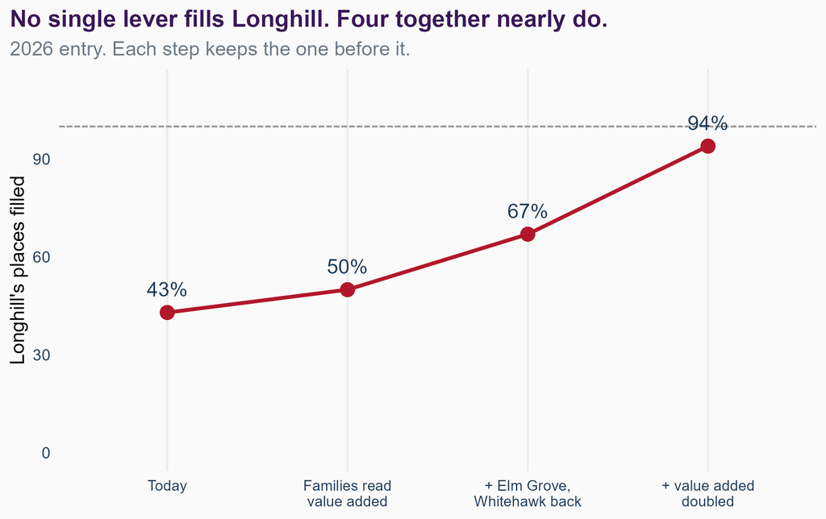

Each choice is modest on its own. **7 points, then 17, then 27.** None would survive a committee on its own merits. Together they take a school from 43% full to 94%.

**Segregation rises**, 0.117 to 0.188. That is the honest cost.

But *How to Pull the Right Lever* finds the attainment model **disagrees about direction** between disadvantaged and other pupils — so deconcentration bought with longer journeys is unlikely to help the children it is meant to.

You cannot reason about this in a committee paper. Every lever moves every other one, and you have to **see each choice land**.

# Concluding Thoughts

## What I would say to a colleague

**It does not replace knowing things.** Every moment that mattered in this project turned on domain knowledge I had and it did not.

**It does collapse the cost of trying.** The scenarios I tested would each have been a week of work. Testing twenty of them was previously impossible, so I would have tested two.

**It writes better documentation than I do**, because it never gets bored of writing it.

**It needs supervision that looks like peer review**, not like proofreading.

**The bottleneck moved.** It is no longer implementation. It is knowing which question is worth asking.

## Open questions

- **Authorship.** What is the honest way to describe this on a paper? I directed every step and verified every output — but I did not write the code.
- **Verification at speed.** I can generate analysis faster than I can properly check it. That is a new kind of risk.
- **Reproducibility of the process.** The code is reproducible. The *conversation* that produced it is not, in any meaningful sense.
- **Who else can do this?** This worked because I could tell right from wrong. What happens when the person in the loop cannot?

## What About Collective Intelligence?

- AI and expert input has accelerated the development of a working simulation of the city’s schools that anyone (politicians, policy makers, senior leadership in schools, council officers, parents) can experiment with
- Still a gap between knowledge of how a system operates -> understanding impacts of different policy levers -> arriving at a sustainable and equitable solution for the city
- Collective Intelligence potential, but barriers still to clear:
  - Awareness
  - Buy in from key players
  - Using the tool to surface enough different ideas to allow the good ones to emerge

## Links

- The analysis — https://adamdennett.github.io/bh-school-system/
- The simulator — https://adamdennett-bh-school-system.share.connect.posit.cloud/
- The national report — https://adamdennett.github.io/school_attainment_tool/
- Everything is open source on GitHub

Happy to be argued with — particularly about the open questions.

# Any Questions?

[figure not shown]